# Statistical Inference

Yuani

23 August 2015

In this project, we will investigate the exponential distribution in R and compare it with the Central Limit Theorem. The exponential distribution can will be simulated in R with rexp(n, lambda) where lambda is the rate parameter.

The mean of exponential distribution is 1/lambda and the standard deviation is also 1/lambda. Lambda = 0.2 for all of the simulations. We will investigate the distribution of averages of 40 exponentials, with 1000 simulations.

### 1. Show the sample mean and compare it to the theoretical mean of the distribution.

```r
#defininig variables
lambda <- 0.2
n <- 40
simulations <- 1:1000
#Set seed for reproducibility
set.seed(120)
#run simulation
sim.means <- data.frame(x=sapply(simulations,function(x) {mean(rexp(n,lambda))}))
head(sim.means)
```

```
##          x
## 1 5.091177
## 2 4.323641
## 3 5.139638
## 4 4.980668
## 5 3.864485
## 6 4.496848
```

```r
samplemean <- mean(sim.means$x)
samplemean
```

```
## [1] 5.03946
```

```r
expectedmean <- 1/lambda
expectedmean
```

```
## [1] 5
```

Based on the above simulation, we see that the sample mean was very close to the theoretical mean of 5.

### 2. Show how variable the sample is (via variance) and compare it to the theoretical variance of the distribution.

```r
samplesd <- sd(sim.means$x)
samplesd
```

```
## [1] 0.7865754
```

```r
samplevar <- var(sim.means$x)
samplevar
```

```
## [1] 0.6187008
```

```r
expectedsd <- (1/lambda)/sqrt(40)
expectedsd
```

```
## [1] 0.7905694
```

```r
expectedvar <- expectedsd^2
expectedvar
```

```
## [1] 0.625
```

Based on the above simulation, we see that the sample variance and theoretical variance are close as well.

### 3. Show that the distribution is approximately normal.

```
## stat_bin: binwidth defaulted to range/30. Use 'binwidth = x' to adjust this.
```

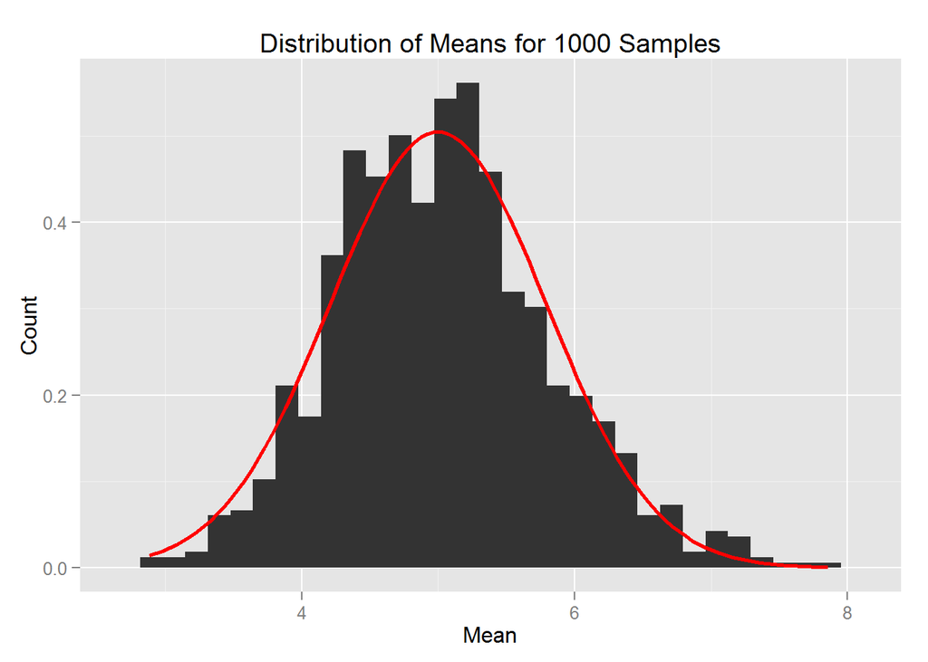

```r
library(ggplot2)
ggplot(data=sim.means,aes(x=x)) + geom_histogram(aes(y=..density..))+labs(title="Distribution of Means for 1000 Samples") +  labs(x="Mean", y="Count") +
stat_function(fun = dnorm, arg=list(mean=expectedmean,sd=expectedsd),color="red",size=1)
```

The histogram shows the distribution of the sample means from the simulation while the red line shows a normal distribution. By overlaping the 2 graphs together, we can see that the distribution is approximately normal.